# Assignment 4 - ST464

Ciarán Ó hAoláin - 17309103

17:05:25 23 April, 2020

## Question 2

### (a)

#### Generalised Additive Model

```r
set.seed(123)
s <- sample(nrow(Boston), round(.6 * nrow(Boston)))
boston_train <- Boston[s, ]
boston_test <- Boston[-s, ]
boston_fit_gma <-
  gam(dis ~ s(medv, 4) + s(age, 4) + s(nox, 4), data = boston_train)
summary(boston_fit_gma)
```

```
##
## Call: gam(formula = dis ~ s(medv, 4) + s(age, 4) + s(nox, 4), data = boston_train)
## Deviance Residuals:
##      Min       1Q   Median       3Q      Max
## -2.30586 -0.62838 -0.06918  0.44791  5.28535
##
## (Dispersion Parameter for gaussian family taken to be 1.0718)
##
##     Null Deviance: 1494.363 on 303 degrees of freedom
## Residual Deviance: 311.8889 on 291.0001 degrees of freedom
## AIC: 898.5028
##
## Number of Local Scoring Iterations: 2
##
## Anova for Parametric Effects
##             Df Sum Sq Mean Sq F value    Pr(>F)
## s(medv, 4)   1  86.20   86.20  80.425 < 2.2e-16 ***
## s(age, 4)    1 547.51  547.51 510.838 < 2.2e-16 ***
## s(nox, 4)    1 267.19  267.19 249.295 < 2.2e-16 ***
## Residuals  291 311.89    1.07
## ---
## Signif. codes:  0 '***' 0.001 '**' 0.01 '*' 0.05 '.' 0.1 ' ' 1
##
## Anova for Nonparametric Effects
##             Npar Df Npar F     Pr(F)
## (Intercept)
## s(medv, 4)        3  4.914  0.002403 **
## s(age, 4)         3  0.868  0.457926
## s(nox, 4)         3 44.385 < 2.2e-16 ***
## ---
## Signif. codes:  0 '***' 0.001 '**' 0.01 '*' 0.05 '.' 0.1 ' ' 1
```

### (b)

#### Plot of GAM

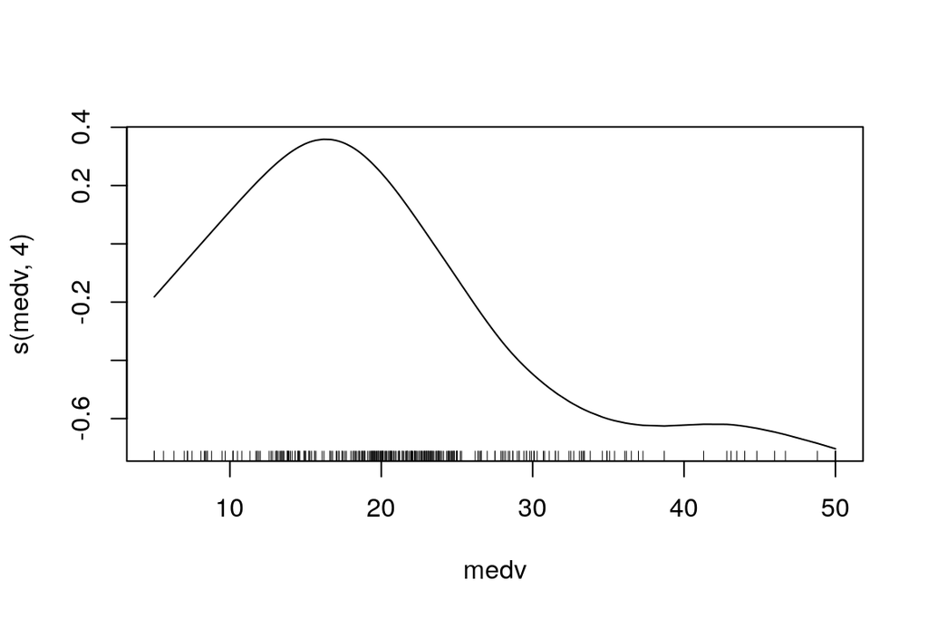

```r
plot.Gam(boston_fit_gma, terms = "s(medv, 4)")
```

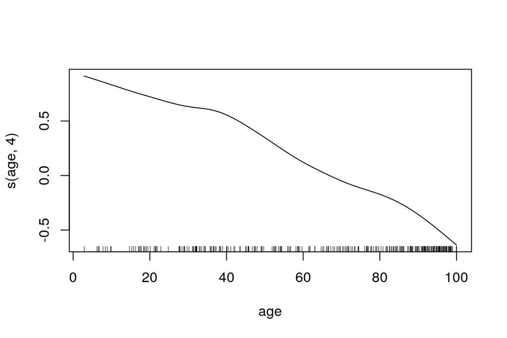

```r
plot.Gam(boston_fit_gma, terms = "s(age, 4)")
```

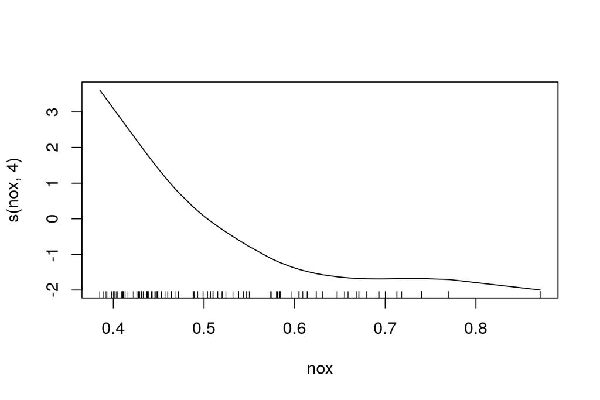

```r
plot.Gam(boston_fit_gma, terms = "s(nox, 4)")
```

A linear term may be appropriate for the `age` predictor.

### (c)

#### GAM Simplification

```r
boston_fit_simp <-
  gam(dis ~ s(medv, 4) + age + s(nox, 4), data = boston_train)
summary(boston_fit_simp)
```

```
##
## Call: gam(formula = dis ~ s(medv, 4) + age + s(nox, 4), data = boston_train)
## Deviance Residuals:
##      Min       1Q   Median       3Q      Max
## -2.31647 -0.63863 -0.07227  0.47228  5.36209
##
## (Dispersion Parameter for gaussian family taken to be 1.0694)
##
##     Null Deviance: 1494.363 on 303 degrees of freedom
## Residual Deviance: 314.3927 on 294 degrees of freedom
## AIC: 894.9336
##
## Number of Local Scoring Iterations: 2
##
## Anova for Parametric Effects
##             Df Sum Sq Mean Sq F value    Pr(>F)
## s(medv, 4)   1  88.70   88.70   82.95 < 2.2e-16 ***
## age          1 541.27  541.27  506.16 < 2.2e-16 ***
## s(nox, 4)    1 273.21  273.21  255.49 < 2.2e-16 ***
## Residuals  294 314.39    1.07
## ---
## Signif. codes:  0 '***' 0.001 '**' 0.01 '*' 0.05 '.' 0.1 ' ' 1
##
## Anova for Nonparametric Effects
##             Npar Df Npar F     Pr(F)
## (Intercept)
## s(medv, 4)        3  5.257  0.001513 **
## age
## s(nox, 4)         3 44.379 < 2.2e-16 ***
## ---
## Signif. codes:  0 '***' 0.001 '**' 0.01 '*' 0.05 '.' 0.1 ' ' 1
```

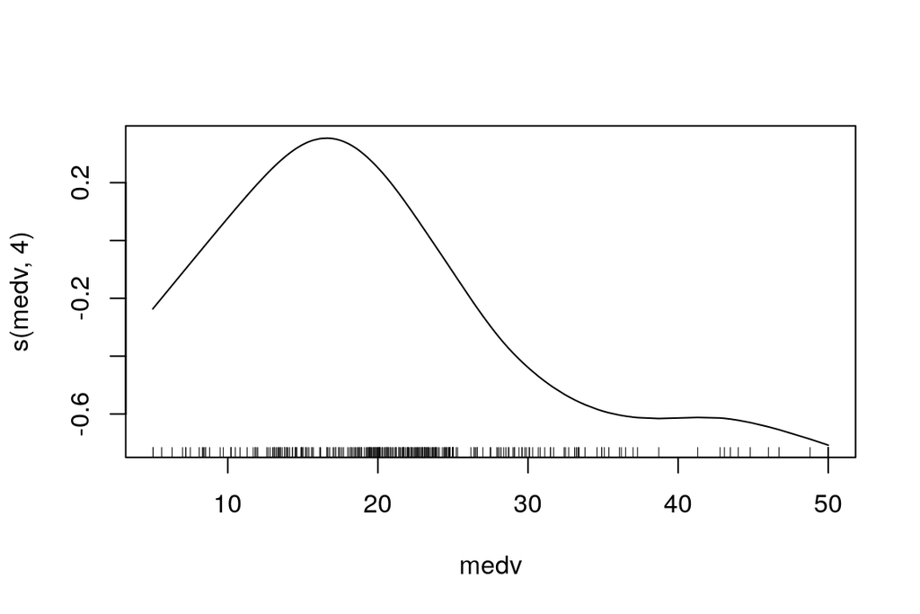

```r
plot.Gam(boston_fit_simp, terms = "s(medv, 4)")
```

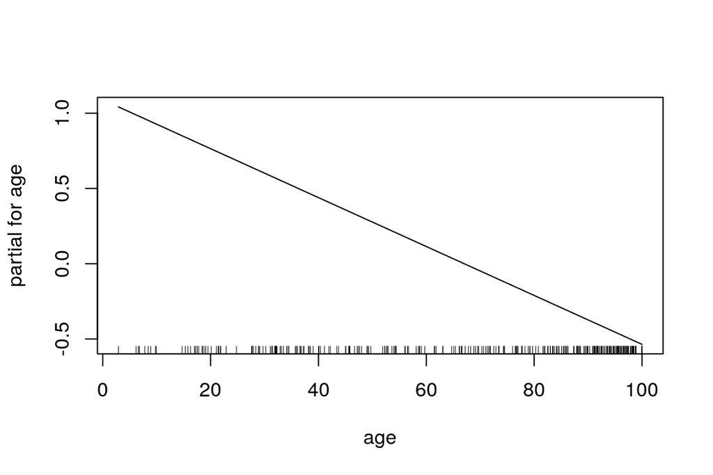

```r
plot.Gam(boston_fit_simp, terms = "age")
```

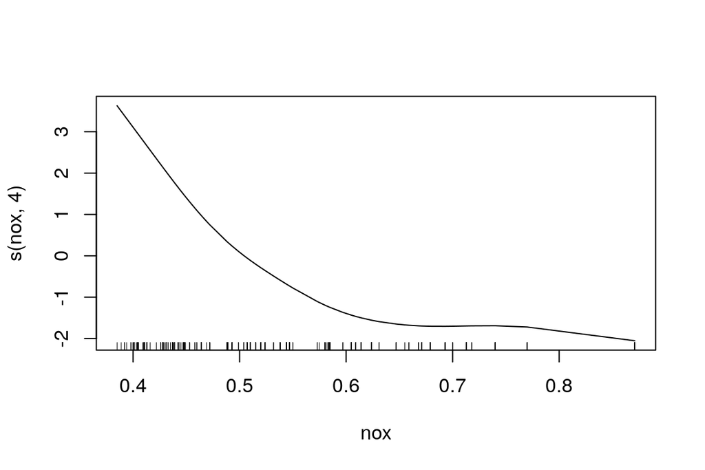

```r
plot.Gam(boston_fit_simp, terms = "s(nox, 4)")
```

```r
anova(boston_fit_gma, boston_fit_simp)
```

```
## Analysis of Deviance Table
##
## Model 1: dis ~ s(medv, 4) + s(age, 4) + s(nox, 4)
## Model 2: dis ~ s(medv, 4) + age + s(nox, 4)
##   Resid. Df Resid. Dev      Df Deviance Pr(>Chi)
## 1       291     311.89
## 2       294     314.39 -2.9999  -2.5037   0.5056
```

Our anova yields a p-value of 0.5056, therefore these two models are not significantly different.  
This tells us that the spline for `age` is not necessary.

```r
# Check training and test MSE for GAM and simplified GAM
train_error <-
  mean((
    predict(boston_fit_gma, newdata = boston_train) - boston_train$dis
  ) ^ 2)
test_error <-
  mean((
    predict(boston_fit_gma, newdata = boston_test) - boston_test$dis
  ) ^ 2)
train_error
```

```
## [1] 1.02594
```

```r
test_error
```

```
## [1] 0.8835129
```

```r
train_error <-
  mean((
    predict(boston_fit_simp, newdata = boston_train) - boston_train$dis
  ) ^ 2)
test_error <-
  mean((
    predict(boston_fit_simp, newdata = boston_test) - boston_test$dis
  ) ^ 2)
train_error
```

```
## [1] 1.034173
```

```r
test_error
```

```
## [1] 0.8842216
```

The training and test MSE of the GAM are 1.02594 and 0.8835129 respectively.  
The training and test MSE of the simplified GAM are 1.034173 and 0.8842216 respectively.  
The simplified GAM has a slightly higher error than the original GAM.

## Question 4

### (a)

#### Tree

```r
boston_tree <- tree(dis ~ medv + age + nox, data = boston_train)
summary(boston_tree)
```

```
##
## Regression tree:
## tree(formula = dis ~ medv + age + nox, data = boston_train)
## Variables actually used in tree construction:
## [1] "nox"  "medv"
## Number of terminal nodes:  5
## Residual mean deviance:  1.035 = 309.4 / 299
## Distribution of residuals:
##     Min.  1st Qu.   Median     Mean  3rd Qu.     Max.
## -2.14700 -0.57740 -0.07306  0.00000  0.42270  5.04400
```

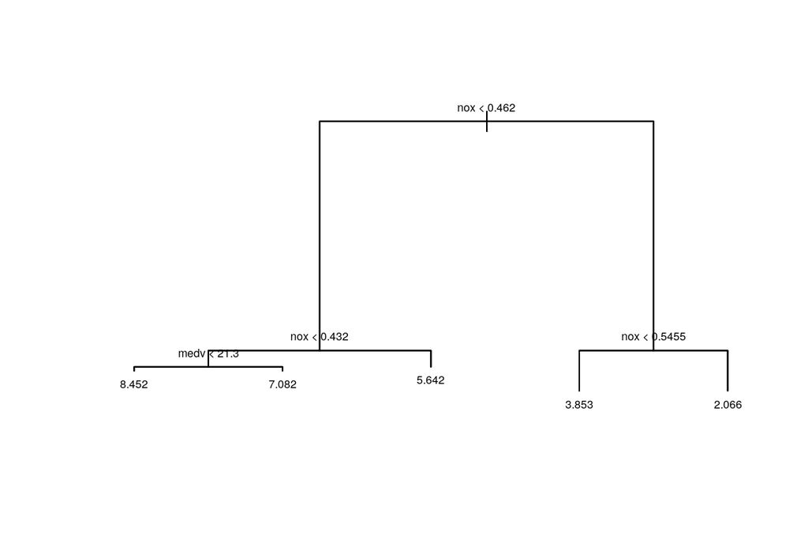

```r
plot(boston_tree)
text(boston_tree, cex = .5, pretty = 0)
```

```r
train_error <-
  mean((predict(boston_tree, newdata = boston_train) - boston_train$dis) ^
         2)
test_error <-
  mean((predict(boston_tree, newdata = boston_test) - boston_test$dis) ^
         2)
train_error
```

```
## [1] 1.01777
```

```r
test_error
```

```
## [1] 0.8456966
```

The training and test MSE of the Tree Model are 1.01777 and 0.8456966 respectively.

### (b)

#### Pruned Tree

```r
cvtree <- cv.tree(boston_tree)
cvtree
```

```
## $size
## [1] 5 4 3 2 1
##
## $dev
## [1]  423.8695  396.7918  417.6922  564.0185 1508.4663
##
## $k
## [1]      -Inf  16.25844  66.70223 164.37812 937.62223
##
## $method
## [1] "deviance"
##
## attr(,"class")
## [1] "prune"         "tree.sequence"
```

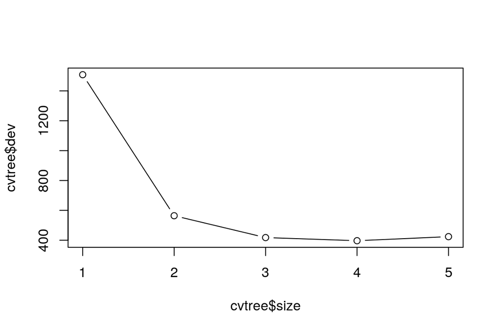

```r
plot(cvtree$size, cvtree$dev , type = "b")
```

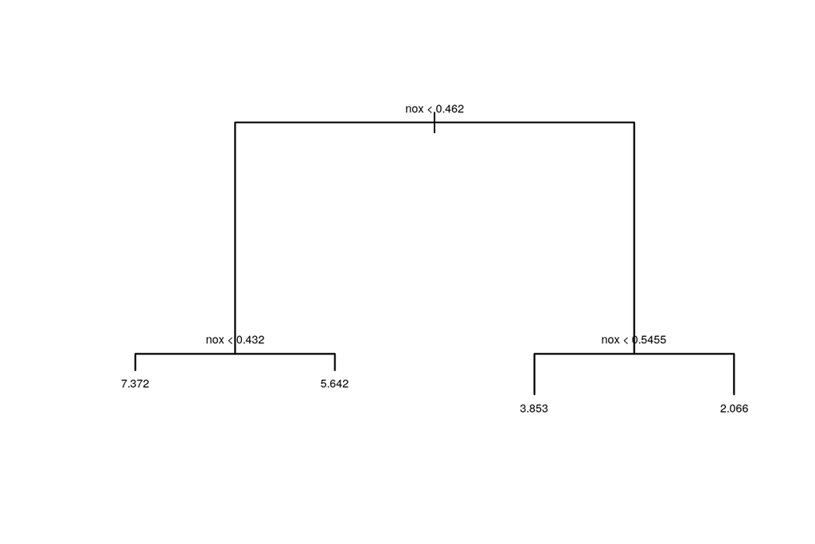

```r
w <- cvtree$size[which.min(cvtree$dev)]
pruned_tree <- prune.tree(boston_tree, best = w)
plot(pruned_tree)
text(pruned_tree, cex = .5, pretty = 0)
```

```r
train_error <-
  mean((predict(pruned_tree, newdata = boston_train) - boston_train$dis) ^
         2)
test_error <-
  mean((predict(pruned_tree, newdata = boston_test) - boston_test$dis) ^
         2)
train_error
```

```
## [1] 1.071252
```

```r
test_error
```

```
## [1] 0.8464587
```

The tree with 4 nodes has the lowest `dev`, we try to prune this tree.  
The training and test MSE of the Pruned Tree Model are 1.071252 and 0.8464587 respectively. These values both give a MSE higher than that of the tree in (a).

### (c)

#### Random Forest

```r
boston_rf <- randomForest(dis ~ medv + age + nox, data = boston_train)
train_error <-
  mean((predict(boston_rf, newdata = boston_train) - boston_train$dis) ^
         2)
test_error <-
  mean((predict(boston_rf, newdata = boston_test) - boston_test$dis) ^ 2)
train_error
```

```
## [1] 0.2181938
```

```r
test_error
```

```
## [1] 0.7266279
```

The training and test MSE of the Random Forest Model are 0.2181938 and 0.7266279 respectively.

### (d)

#### Comparison of Models

The training and test MSE of the GAM are 1.02594 and 0.8835129 respectively.  
The training and test MSE of the simplified GAM are 1.034173 and 0.8842216 respectively.  
The training and test MSE of the Tree Model are 1.01777 and 0.8456966 respectively.  
The training and test MSE of the Pruned Tree Model are 1.071252 and 0.8464587 respectively.  
The training and test MSE of the Random Forest Model are 0.2181938 and 0.7266279 respectively.

Clearly the Random Forest Model yields the lowest MSE on the training and test data compared to all of the other models.  
So the Random Forest Model gives the best fit to the test data here.  
The Tree Model (with no additional pruning) gave the second best fit on the test data, followed by the Pruned Tree Model.  
Finally, the GAM gave the worst fit to the test data. However, the difference in MSE between all the above models was quite small.